# Ejercicio 1: El Perfil Sociodemográfico de la ENOE

## ¿De qué trata este laboratorio?

En este laboratorio vamos a explorar una base de datos real y grande: la **Encuesta Nacional de Ocupación y Empleo (ENOE)** del INEGI, correspondiente al cuarto trimestre de 2025 (una muestra de 50,000 personas encuestadas).

La ENOE es la encuesta que usa el gobierno de México para calcular indicadores como la tasa de desempleo o el ingreso promedio de los trabajadores. Es una base “real”: tiene más de 100 columnas, muchas con códigos numéricos en vez de texto (por ejemplo, `sex = 1` significa “Hombre”), y tiene valores faltantes que hay que tratar con cuidado.

**Nota para quienes toman el curso:** en este laboratorio todavía no usamos funciones propias (`function() {...}`). Nos vamos a concentrar en la **población ocupada** para el análisis de edad, ingreso y correlaciones; el grupo de **desocupados** solo lo usamos para calcular la tasa de desocupación, uno de los tres indicadores clásicos del mercado laboral.

## 0. Preparación del entorno

Antes de trabajar necesitamos cargar los paquetes que usaremos. Cada uno tiene un propósito distinto:

- `dplyr`: para filtrar, seleccionar y transformar datos (`filter()`, `select()`, `mutate()`, `summarise()`).
- `ggplot2`: para hacer gráficas.
- `scales`: para dar formato a los números de los ejes (comas, porcentajes).
- `openxlsx`: para leer archivos de Excel (`.xlsx`).
- `Hmisc`: para calcular medias y cuantiles **ponderados** (los usaremos al final).
- `corrplot`: para graficar la matriz de correlación.

```r
# Si no tienes instalado algún paquete, quita el "#" de la siguiente línea
# y ejecútala una sola vez:
# install.packages(c("dplyr", "ggplot2", "scales", "openxlsx", "Hmisc", "corrplot"))

library(dplyr)
library(ggplot2)
library(scales)
library(openxlsx)
library(Hmisc)
library(corrplot)

# Definimos el directorio de trabajo: aquí es donde R va a buscar el archivo
# de Excel y donde va a guardar lo que le pidamos guardar.
# NOTA: dentro de un archivo .Rmd, setwd() solo aplica a ese "chunk".
# Es más seguro colocar el .Rmd, el .xlsx y la carpeta "salidas" en la
# misma carpeta, y no usar setwd() en absoluto (ver nota abajo).
setwd("~/Cursos-R/Ejercicios/Ejercicio-1")
```

> **Nota importante sobre `setwd()` en R Markdown:** cuando usas `Knit` para generar el HTML, R Markdown normalmente usa como directorio de trabajo la carpeta donde está guardado el propio archivo `.Rmd`, sin importar lo que pongas en `setwd()`. Si tu archivo de Excel no aparece o marca error de “no se encuentra el archivo”, la solución más simple es: 1. Guardar el `.Rmd` en la misma carpeta que `enoe_2025_4t_sample_50k.xlsx`. 2. Quitar o comentar la línea `setwd(...)`. 3. Leer el archivo solo con su nombre, por ejemplo: `read.xlsx("enoe_2025_4t_sample_50k.xlsx", ...)`.

## 1. Lectura de la base de datos

Leemos el archivo de Excel una sola vez y lo guardamos en un objeto llamado `enoe`. Le decimos a R que trate las celdas vacías, con un espacio, o con el texto `"NA"` como valores faltantes.

```r
enoe <- read.xlsx(
  "enoe_2025_4t_sample_50k.xlsx",
  na.strings = c("", " ", "NA")
)
```

Con `View()` normalmente abrimos una ventana para inspeccionar la base como si fuera una hoja de cálculo. **Esta función no debe usarse dentro de un chunk que se va a convertir a HTML** porque abre una ventana interactiva de RStudio y detiene (o rompe) el proceso de generación del documento. Para explorar la base de forma interactiva, ejecuta `View(enoe)` directamente en la consola de RStudio, no dentro del `.Rmd`.

```r
# En el documento HTML usamos head() en su lugar, que sí se puede imprimir.
head(enoe)
```

|  | r_def | cve_loc | cve_mun | est | est_d_tri | est_d_men | cve_ageb | t_loc_tri | t_loc_men | cd_a | cve_ent | con | upm | d_sem | n_pro_viv | v_sel | n_hog | h_mud | n_ent | per | n_ren | c_res | par_c | sex | eda | nac_dia | nac_mes | nac_anio | l_nac_c | … |
| --- | --- | --- | --- | --- | --- | --- | --- | --- | --- | --- | --- | --- | --- | --- | --- | --- | --- | --- | --- | --- | --- | --- | --- | --- | --- | --- | --- | --- | --- | --- |
| 1 | 0 | NA | 16 | 20 | 1005 | 1005 | 0 | 3 | 3 | 84 | 22 | 50062 | 2205033 | 101 | 68 | 59 | 1 | 0 | 3 | 425 | 1 | 1 | 101 | 1 | 76 | 99 | 9 | 1949 | 22 | … |
| 2 | 0 | NA | 20 | 30 | 703 | 703 | 0 | 1 | 1 | 5 | 11 | 40424 | 1107277 | 109 | 23 | 53 | 1 | 0 | 3 | 425 | 2 | 1 | 301 | 1 | 8 | 23 | 6 | 2017 | 11 | … |
| 3 | 0 | NA | 5 | 20 | 690 | 690 | 0 | 1 | 1 | 26 | 10 | 41277 | 1000822 | 107 | 65 | 51 | 1 | 0 | 3 | 425 | 3 | 1 | 408 | 1 | 12 | 13 | 8 | 2013 | 10 | … |
| 4 | 0 | NA | 7 | 30 | 862 | 862 | 0 | 1 | 1 | 29 | 17 | 40133 | 1701341 | 213 | 119 | 2 | 1 | 0 | 2 | 425 | 2 | 1 | 201 | 2 | 63 | 7 | 8 | 1962 | 17 | … |
| 5 | 0 | NA | 24 | 30 | 1220 | 1220 | 0 | 2 | 2 | 83 | 32 | 50050 | 3201842 | 303 | 132 | 17 | 1 | 0 | 1 | 425 | 3 | 1 | 301 | 1 | 5 | 23 | 1 | 2020 | 1 | … |
| 6 | 0 | NA | 4 | 30 | 1081 | 1081 | 0 | 1 | 1 | 18 | 27 | 40061 | 2705145 | 304 | 111 | 4 | 1 | 0 | 1 | 425 | 2 | 1 | 301 | 2 | 24 | 6 | 7 | 2001 | 27 | … |

## 2. Exploración inicial de la base

Antes de hacer cualquier cálculo, siempre conviene mirar la estructura de los datos: cuántas filas y columnas tiene, y qué tipo de dato es cada columna.

```r
# str() muestra el tipo de cada columna (numérica, texto, etc.) y algunos
# valores de ejemplo.
str(enoe)
```

```
## 'data.frame':    50000 obs. of  115 variables:
##  $ r_def     : num  0 0 0 0 0 0 0 0 0 0 ...
##  $ cve_loc   : num  NA NA NA NA NA NA NA NA NA NA ...
##  $ cve_mun   : num  16 20 5 7 24 4 2 28 41 35 ...
##  $ est       : num  20 30 20 30 30 30 20 40 20 20 ...
##  $ est_d_tri : num  1005 703 690 862 1220 ...
##  $ est_d_men : num  1005 703 690 862 1220 ...
##  $ cve_ageb  : num  0 0 0 0 0 0 0 0 0 0 ...
##  $ t_loc_tri : num  3 1 1 1 2 1 1 1 1 4 ...
##  $ t_loc_men : num  3 1 1 1 2 1 1 1 1 4 ...
##  $ cd_a      : num  84 5 26 29 83 18 28 12 8 86 ...
##  $ cve_ent   : num  22 11 10 17 32 27 4 30 31 24 ...
##  $ con       : num  50062 40424 41277 40133 50050 ...
##  $ upm       : num  2205033 1107277 1000822 1701341 3201842 ...
##  $ d_sem     : num  101 109 107 213 303 304 309 208 505 201 ...
```

[output cut: 86 more lines]

```r
# dim() nos da el número de filas y columnas.
dim(enoe)
```

```
## [1] 50000   115
```

```r
# names() y colnames() hacen lo mismo: nos muestran el nombre de cada columna.
names(enoe)
```

```
##   [1] "r_def"      "cve_loc"    "cve_mun"    "est"        "est_d_tri"
##   [6] "est_d_men"  "cve_ageb"   "t_loc_tri"  "t_loc_men"  "cd_a"
##  [11] "cve_ent"    "con"        "upm"        "d_sem"      "n_pro_viv"
##  [16] "v_sel"      "n_hog"      "h_mud"      "n_ent"      "per"
##  [21] "n_ren"      "c_res"      "par_c"      "sex"        "eda"
##  [26] "nac_dia"    "nac_mes"    "nac_anio"   "l_nac_c"    "cs_p12"
##  [31] "cs_p13_1"   "cs_p13_2"   "cs_p14_c"   "cs_p15"     "cs_p16"
##  [36] "cs_p17"     "n_hij"      "e_con"      "cs_p20a_1"  "cs_p20a_c"
##  [41] "cs_p20b_1"  "cs_p20b_c"  "cs_p20c_1"  "cs_ad_mot"  "cs_p21_des"
##  [46] "cs_ad_des"  "cs_nr_mot"  "cs_p23_des" "cs_nr_ori"  "ur"
##  [51] "zona"       "salario"    "fac_tri"    "fac_men"    "clase1"
##  [56] "clase2"     "clase3"     "pos_ocu"    "seg_soc"    "rama"
##  [61] "c_ocu11c"   "ing7c"      "dur9c"      "emple7c"    "medica5c"
##  [66] "buscar5c"   "rama_est1"  "rama_est2"  "dur_est"    "ambito1"
##  [71] "ambito2"    "tue1"       "tue2"       "tue3"       "busqueda"
##  [76] "d_ant_lab"  "d_cexp_est" "dur_des"    "sub_o"      "s_clasifi"
##  [81] "remune2c"   "pre_asa"    "tip_con"    "dispo"      "nodispo"
##  [86] "c_inac5c"   "pnea_est"   "niv_ins"    "eda5c"      "eda7c"
##  [91] "eda12c"     "eda19c"     "hij5c"      "domestico"  "anios_esc"
##  [96] "hrsocup"    "ingocup"    "ing_x_hrs"  "tpg_p8a"    "tcco"
## [101] "cp_anoc"    "imssissste" "ma48me1sm"  "p14apoyos"  "scian"
## [106] "t_tra"      "emp_ppal"   "tue_ppal"   "trans_ppal" "mh_fil2"
## [111] "mh_col"     "sec_ins"    "tipo"       "mes_cal"    "cvegeo"
```

```r
colnames(enoe)
```

```
##   [1] "r_def"      "cve_loc"    "cve_mun"    "est"        "est_d_tri"
##   [6] "est_d_men"  "cve_ageb"   "t_loc_tri"  "t_loc_men"  "cd_a"
##  [11] "cve_ent"    "con"        "upm"        "d_sem"      "n_pro_viv"
##  [16] "v_sel"      "n_hog"      "h_mud"      "n_ent"      "per"
##  [21] "n_ren"      "c_res"      "par_c"      "sex"        "eda"
##  [26] "nac_dia"    "nac_mes"    "nac_anio"   "l_nac_c"    "cs_p12"
##  [31] "cs_p13_1"   "cs_p13_2"   "cs_p14_c"   "cs_p15"     "cs_p16"
##  [36] "cs_p17"     "n_hij"      "e_con"      "cs_p20a_1"  "cs_p20a_c"
##  [41] "cs_p20b_1"  "cs_p20b_c"  "cs_p20c_1"  "cs_ad_mot"  "cs_p21_des"
##  [46] "cs_ad_des"  "cs_nr_mot"  "cs_p23_des" "cs_nr_ori"  "ur"
##  [51] "zona"       "salario"    "fac_tri"    "fac_men"    "clase1"
##  [56] "clase2"     "clase3"     "pos_ocu"    "seg_soc"    "rama"
##  [61] "c_ocu11c"   "ing7c"      "dur9c"      "emple7c"    "medica5c"
##  [66] "buscar5c"   "rama_est1"  "rama_est2"  "dur_est"    "ambito1"
##  [71] "ambito2"    "tue1"       "tue2"       "tue3"       "busqueda"
##  [76] "d_ant_lab"  "d_cexp_est" "dur_des"    "sub_o"      "s_clasifi"
##  [81] "remune2c"   "pre_asa"    "tip_con"    "dispo"      "nodispo"
##  [86] "c_inac5c"   "pnea_est"   "niv_ins"    "eda5c"      "eda7c"
##  [91] "eda12c"     "eda19c"     "hij5c"      "domestico"  "anios_esc"
##  [96] "hrsocup"    "ingocup"    "ing_x_hrs"  "tpg_p8a"    "tcco"
## [101] "cp_anoc"    "imssissste" "ma48me1sm"  "p14apoyos"  "scian"
## [106] "t_tra"      "emp_ppal"   "tue_ppal"   "trans_ppal" "mh_fil2"
## [111] "mh_col"     "sec_ins"    "tipo"       "mes_cal"    "cvegeo"
```

## 3. Revisión de valores faltantes (NA)

Una base tan grande casi siempre tiene columnas con datos faltantes. Vamos a contar cuántos NA tiene cada columna y a graficar las que más tienen.

```r
# colSums(is.na(enoe)) cuenta, para cada columna, cuántas celdas son NA.
na_counts <- colSums(is.na(enoe))
na_counts
```

```
##      r_def    cve_loc    cve_mun        est  est_d_tri  est_d_men   cve_ageb
##          0      50000        458          0          0       2406          0
##  t_loc_tri  t_loc_men       cd_a    cve_ent        con        upm      d_sem
##          0       2406          0          0          0          0          0
##  n_pro_viv      v_sel      n_hog      h_mud      n_ent        per      n_ren
##          0          0          0          0          0          0          0
##      c_res      par_c        sex        eda    nac_dia    nac_mes   nac_anio
##          0       1226       1226       1226       1226       1226       1226
##    l_nac_c     cs_p12   cs_p13_1   cs_p13_2   cs_p14_c     cs_p15     cs_p16
##       1226       3739       3739       3739      39526      40268      39526
##     cs_p17      n_hij      e_con  cs_p20a_1  cs_p20a_c  cs_p20b_1  cs_p20b_c
##       3739      28227       8883       1612       1612       1649       1649
##  cs_p20c_1  cs_ad_mot cs_p21_des  cs_ad_des  cs_nr_mot cs_p23_des  cs_nr_ori
##      49570      48774      49788      48995      49053      49966      49448
##         ur       zona    salario    fac_tri    fac_men     clase1     clase2
##          0          0          0          0          0          0          0
##     clase3    pos_ocu    seg_soc       rama   c_ocu11c      ing7c      dur9c
##          0          0          0          0          0          0          0
##    emple7c   medica5c   buscar5c  rama_est1  rama_est2    dur_est    ambito1
##          0          0          0          0          0          0          0
##    ambito2       tue1       tue2       tue3   busqueda  d_ant_lab d_cexp_est
##          0          0          0          0          0          0          0
##    dur_des      sub_o  s_clasifi   remune2c    pre_asa    tip_con      dispo
##          0          0          0          0          0          0          0
##    nodispo   c_inac5c   pnea_est    niv_ins      eda5c      eda7c     eda12c
##          0          0          0          0          0          0          0
##     eda19c      hij5c  domestico  anios_esc    hrsocup    ingocup  ing_x_hrs
##          0          0          0          0          0          0          0
##    tpg_p8a       tcco    cp_anoc imssissste  ma48me1sm  p14apoyos      scian
##          0          0          0          0          0          0          0
##      t_tra   emp_ppal   tue_ppal trans_ppal    mh_fil2     mh_col    sec_ins
##          0          0          0          0          0          0          0
##       tipo    mes_cal     cvegeo
##          0          0          0
```

```r
# Guardamos esos conteos en una tabla (data.frame) para poder ordenarla
# y graficarla más fácilmente.
total_filas <- nrow(enoe)

na_resumen <- data.frame(
  columna = names(na_counts),
  na_count = na_counts,
  na_percent = round((na_counts / total_filas) * 100, 2)
) %>%
  filter(na_count > 0) %>%
  arrange(desc(na_count))

na_resumen
```

|  | columna | na_count | na_percent |
| --- | --- | --- | --- |
| cve_loc | cve_loc | 50000 | 100.00 |
| cs_p23_des | cs_p23_des | 49966 | 99.93 |
| cs_p21_des | cs_p21_des | 49788 | 99.58 |
| cs_p20c_1 | cs_p20c_1 | 49570 | 99.14 |
| cs_nr_ori | cs_nr_ori | 49448 | 98.90 |
| cs_nr_mot | cs_nr_mot | 49053 | 98.11 |
| cs_ad_des | cs_ad_des | 48995 | 97.99 |
| cs_ad_mot | cs_ad_mot | 48774 | 97.55 |
| cs_p15 | cs_p15 | 40268 | 80.54 |
| cs_p14_c | cs_p14_c | 39526 | 79.05 |

[output cut: 21 more lines]

Ahora graficamos las columnas con más valores faltantes:

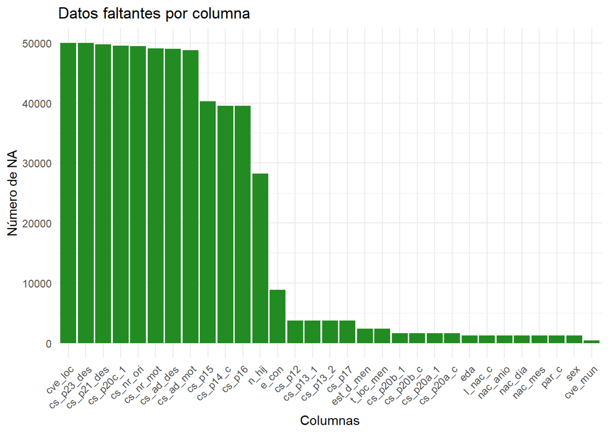

```r
ggplot(na_resumen, aes(x = reorder(columna, -na_count), y = na_count)) +
  geom_bar(stat = "identity", fill = "forestgreen") +
  labs(title = "Datos faltantes por columna",
       x = "Columnas",
       y = "Número de NA") +
  theme_minimal() +
  theme(axis.text.x = element_text(angle = 45, hjust = 1))
```

## 4. Selección de las variables de interés

La base tiene más de 100 columnas, pero la mayoría son claves técnicas del diseño muestral que no vamos a usar en este laboratorio. Nos quedamos solo con las variables relevantes para el mercado laboral, y les damos nombres más fáciles de recordar con `select()`:

```r
mercado_laboral <- enoe %>%
  select(
    entidad     = cve_ent,   # entidad federativa (01 a 32)
    sexo        = sex,       # 1 = Hombre, 2 = Mujer
    edad        = eda,       # edad en años cumplidos
    escolaridad = anios_esc, # años de escolaridad aprobados
    niv_ins     = niv_ins,   # nivel de instrucción (1 a 5)
    clase1      = clase1,    # 1 = Población Económicamente Activa (PEA)
                              # 2 = Población No Económicamente Activa (PNEA)
    clase2      = clase2,    # dentro de la PEA: 1 = Ocupada, 2 = Desocupada
    pos_ocu     = pos_ocu,   # tipo de empleo / posición en la ocupación
    rama        = rama,      # sector de actividad económica (7 categorías)
    ing7c       = ing7c,     # nivel de ingreso en 7 categorías
    ingocup     = ingocup,   # ingreso mensual en pesos (población ocupada)
    ing_x_hrs   = ing_x_hrs, # ingreso por hora trabajada
    horas       = hrsocup,   # horas trabajadas a la semana
    ponderador  = fac_tri    # factor de expansión trimestral
  )

# Revisamos el nuevo data frame: debería tener las mismas filas que "enoe"
# pero muchas menos columnas.
dim(mercado_laboral)
```

```
## [1] 50000    14
```

```r
str(mercado_laboral)
```

```
## 'data.frame':    50000 obs. of  14 variables:
##  $ entidad    : num  22 11 10 17 32 27 4 30 31 24 ...
##  $ sexo       : num  1 1 1 2 1 2 2 2 2 2 ...
##  $ edad       : num  76 8 12 63 5 24 10 46 20 43 ...
##  $ escolaridad: num  0 0 5 12 0 16 0 17 11 9 ...
##  $ niv_ins    : num  1 1 1 4 1 4 1 4 3 3 ...
##  $ clase1     : num  2 0 2 2 0 2 0 1 1 1 ...
##  $ clase2     : num  4 0 4 4 0 4 0 1 1 1 ...
##  $ pos_ocu    : num  0 0 0 0 0 0 0 1 1 1 ...
##  $ rama       : num  0 0 0 0 0 0 0 4 3 3 ...
##  $ ing7c      : num  0 0 0 0 0 0 0 2 1 1 ...
##  $ ingocup    : num  0 0 0 0 0 0 0 13000 6450 6450 ...
##  $ ing_x_hrs  : num  0 0 0 0 0 ...
##  $ horas      : num  0 0 0 0 0 0 0 40 48 42 ...
##  $ ponderador : num  389 223 53 109 171 37 47 203 131 311 ...
```

## 5. Limpieza y recodificación de variables categóricas

En la ENOE, el código `0` casi siempre significa “no aplica” (por ejemplo, `pos_ocu = 0` para alguien que no está ocupado). Si no lo convertimos en NA, R lo va a tratar como un número válido y nuestras estadísticas van a salir mal. Por eso, **primero** convertimos los ceros en NA con `na_if()`, y **después** convertimos la columna en un factor con etiquetas legibles.

```r
mercado_laboral <- mercado_laboral %>%
  mutate(
    # ---- Sexo ----
    sexo = factor(sexo, levels = c(1, 2), labels = c("Hombre", "Mujer")),

    # ---- Población Económicamente Activa / No Activa ----
    clase1 = factor(clase1, levels = c(1, 2),
                     labels = c("PEA", "PNEA")),

    # ---- Condición de ocupación (solo tiene sentido dentro de la PEA) ----
    clase2 = factor(clase2, levels = c(1, 2, 3, 4),
                     labels = c("Ocupada", "Desocupada",
                                "Disponible", "No disponible")),

    # ---- Tipo de empleo / posición en la ocupación ----
    pos_ocu = na_if(pos_ocu, 0),
    pos_ocu = factor(pos_ocu, levels = c(1, 2, 3, 4, 5),
                      labels = c("Subordinado(a) y remunerado(a)",
                                 "Empleador(a)",
                                 "Trabajador(a) por cuenta propia",
                                 "Trabajador(a) sin pago",
                                 "No especificado")),

    # ---- Nivel de instrucción ----
    niv_ins = na_if(niv_ins, 0),
    niv_ins = factor(niv_ins, levels = c(1, 2, 3, 4, 5),
                      labels = c("Primaria incompleta",
                                 "Primaria completa",
                                 "Secundaria completa",
                                 "Medio superior y superior",
                                 "No especificado")),

    # ---- Sector de actividad económica (rama) ----
    rama = na_if(rama, 0),
    rama = factor(rama, levels = 1:7,
                   labels = c("Agropecuario",
                              "Industria extractiva y electricidad",
                              "Industria manufacturera",
                              "Construcción",
                              "Comercio",
                              "Restaurantes y alojamiento",
                              "Otros servicios")),

    # ---- Nivel de ingreso agrupado (7 categorías del INEGI) ----
    ing7c = na_if(ing7c, 0),
    ing7c = factor(ing7c, levels = 1:7,
                    labels = c("Hasta 1 s.m.", "Más de 1 a 2 s.m.",
                               "Más de 2 a 3 s.m.", "Más de 3 a 5 s.m.",
                               "Más de 5 s.m.", "No recibe ingresos",
                               "No especificado")),

    # ---- Variables numéricas: el 0 también significa "no aplica" ----
    ingocup   = na_if(ingocup, 0),
    ing_x_hrs = na_if(ing_x_hrs, 0),
    horas     = na_if(horas, 0)
  )

# Revisamos cómo quedaron las variables recodificadas.
summary(mercado_laboral$sexo)
```

```
## Hombre  Mujer    NAs
##  23221  25553   1226
```

```r
summary(mercado_laboral$pos_ocu)
```

```
##  Subordinado(a) y remunerado(a)                    Empleador(a)
##                           16137                            1369
## Trabajador(a) por cuenta propia          Trabajador(a) sin pago
##                            4559                             787
##                 No especificado                             NAs
##                               0                           27148
```

```r
summary(mercado_laboral$niv_ins)
```

```
##       Primaria incompleta         Primaria completa       Secundaria completa
##                      9270                      7788                     12880
## Medio superior y superior           No especificado                       NAs
##                     16125                       101                      3836
```

## 6. Población en edad de trabajar, PEA, ocupados y desocupados

Ahora vamos a construir, paso a paso, los grupos de población que se usan para calcular los indicadores del mercado laboral. Cada grupo es un subconjunto del anterior:

```r
# Población en Edad de Trabajar (PET): en México, se considera a partir de
# los 15 años.
PET <- mercado_laboral %>%
  filter(edad >= 15)

# ¿Cuántas personas se quedaron fuera de la PET por ser menores de 15 años?
cat("Personas totales en la base:", nrow(mercado_laboral), "\n")
```

```
## Personas totales en la base: 50000
```

```r
cat("Personas en la PET (15 años o más):", nrow(PET), "\n")
```

```
## Personas en la PET (15 años o más): 38628
```

```r
cat("Personas menores de 15 años (fuera de la PET):",
    nrow(mercado_laboral) - nrow(PET), "\n\n")
```

```
## Personas menores de 15 años (fuera de la PET): 11372
```

```r
# Población Económicamente Activa (PEA): dentro de la PET, quienes trabajan
# o buscan trabajo.
PEA <- PET %>%
  filter(clase1 == "PEA")

cat("Personas en la PEA:", nrow(PEA), "\n")
```

```
## Personas en la PEA: 23318
```

```r
cat("Personas en la PNEA (dentro de la PET):", nrow(PET) - nrow(PEA), "\n\n")
```

```
## Personas en la PNEA (dentro de la PET): 15310
```

```r
# Ocupados y desocupados son subconjuntos de la PEA.
ocupados <- PEA %>%
  filter(clase2 == "Ocupada")

desocupados <- PEA %>%
  filter(clase2 == "Desocupada")

cat("Personas ocupadas:", nrow(ocupados), "\n")
```

```
## Personas ocupadas: 22747
```

```r
cat("Personas desocupadas:", nrow(desocupados), "\n")
```

```
## Personas desocupadas: 571
```

### Indicadores del mercado laboral (sin ponderar, por ahora)

Con estos cuatro grupos ya podemos calcular los tres indicadores más conocidos del mercado laboral. Por ahora los calculamos **sin usar el ponderador** (más adelante veremos qué cambia si lo usamos):

```r
# Tasa de participación: qué proporción de la PET participa en el mercado
# laboral (trabajando o buscando trabajo).
tasa_participacion <- nrow(PEA) / nrow(PET) * 100
cat("Tasa de participación (sin ponderar):", round(tasa_participacion, 2), "%\n")
```

```
## Tasa de participación (sin ponderar): 60.37 %
```

```r
# Tasa de desocupación: qué proporción de la PEA no tiene trabajo pero lo
# busca.
tasa_desocupacion <- nrow(desocupados) / nrow(PEA) * 100
cat("Tasa de desocupación (sin ponderar):", round(tasa_desocupacion, 2), "%\n")
```

```
## Tasa de desocupación (sin ponderar): 2.45 %
```

```r
# Tasa de ocupación: qué proporción de la PET tiene trabajo.
tasa_ocupacion <- nrow(ocupados) / nrow(PET) * 100
cat("Tasa de ocupación (sin ponderar):", round(tasa_ocupacion, 2), "%\n")
```

```
## Tasa de ocupación (sin ponderar): 58.89 %
```

## 7. Estadística descriptiva de la edad: población ocupada

Vamos a calcular las medidas de tendencia central (media, mediana, moda) y de dispersión (desviación estándar, varianza, rango) para la edad de las personas ocupadas.

```r
# ---- Media ----
media_edad_ocupados <- mean(ocupados$edad, na.rm = TRUE)
media_edad_ocupados
```

```
## [1] 40.57819
```

```r
# ---- Mediana ----
mediana_edad_ocupados <- median(ocupados$edad, na.rm = TRUE)
mediana_edad_ocupados
```

```
## [1] 40
```

```r
# ---- Desviación estándar ----
sd_edad_ocupados <- sd(ocupados$edad, na.rm = TRUE)
sd_edad_ocupados
```

```
## [1] 14.36926
```

```r
# ---- Varianza ----
var_edad_ocupados <- var(ocupados$edad, na.rm = TRUE)
var_edad_ocupados
```

```
## [1] 206.4755
```

```r
# ---- Rango (valor mínimo y máximo) ----
rango_edad_ocupados <- range(ocupados$edad, na.rm = TRUE)
rango_edad_ocupados
```

```
## [1] 15 98
```

R base no trae una función para calcular la **moda** (el valor más frecuente), así que la calculamos “a mano” con `table()`, que cuenta cuántas veces aparece cada edad:

```r
# table() cuenta cuántas veces aparece cada valor de edad.
tabla_edad_ocupados <- table(ocupados$edad)

# El valor máximo de esa tabla es la frecuencia más alta.
frecuencia_maxima_ocupados <- max(tabla_edad_ocupados)

# Buscamos qué edad(es) tienen esa frecuencia máxima: esa es la moda.
moda_edad_ocupados <- names(tabla_edad_ocupados)[tabla_edad_ocupados == frecuencia_maxima_ocupados]
moda_edad_ocupados
```

```
## [1] "30"
```

Imprimimos un resumen completo:

```r
cat("EDAD de la población ocupada\n")
```

```
## EDAD de la población ocupada
```

```r
cat(" Media          :", round(media_edad_ocupados, 2), "\n")
```

```
##  Media          : 40.58
```

```r
cat(" Mediana        :", mediana_edad_ocupados, "\n")
```

```
##  Mediana        : 40
```

```r
cat(" Desv. estándar :", round(sd_edad_ocupados, 2), "\n")
```

```
##  Desv. estándar : 14.37
```

```r
cat(" Varianza       :", round(var_edad_ocupados, 2), "\n")
```

```
##  Varianza       : 206.48
```

```r
cat(" Rango          :", rango_edad_ocupados[1], "a", rango_edad_ocupados[2], "\n")
```

```
##  Rango          : 15 a 98
```

```r
cat(" Moda           :", moda_edad_ocupados, "\n\n")
```

```
##  Moda           : 30
```

Y graficamos la distribución con un histograma, marcando la media y la mediana con líneas punteadas:

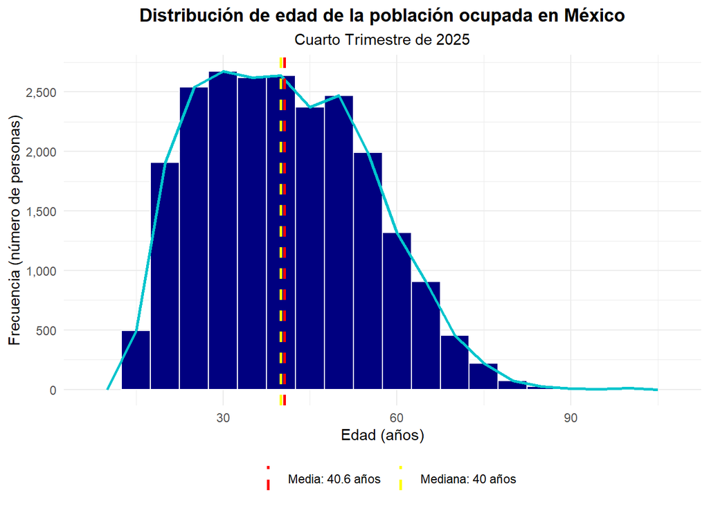

```r
label_media_ocupados   <- paste0("Media: ", round(media_edad_ocupados, 1), " años")
label_mediana_ocupados <- paste0("Mediana: ", round(mediana_edad_ocupados, 1), " años")

ggplot(ocupados, aes(x = edad)) +
  geom_histogram(binwidth = 5, fill = "navy", color = "white") +
  geom_freqpoly(binwidth = 5, color = "#00C5CD", linewidth = 1) +
  geom_vline(aes(xintercept = media_edad_ocupados, color = label_media_ocupados),
             linetype = "dashed", linewidth = 1) +
  geom_vline(aes(xintercept = mediana_edad_ocupados, color = label_mediana_ocupados),
             linetype = "dashed", linewidth = 1) +
  scale_color_manual(name = "", values = setNames(c("red", "yellow"),
                                                    c(label_media_ocupados, label_mediana_ocupados))) +
  scale_y_continuous(labels = comma, breaks = pretty_breaks()) +
  labs(title = "Distribución de edad de la población ocupada en México",
       subtitle = "Cuarto Trimestre de 2025",
       x = "Edad (años)", y = "Frecuencia (número de personas)") +
  theme_minimal() +
  theme(plot.title = element_text(face = "bold", hjust = 0.5),
        plot.subtitle = element_text(hjust = 0.5),
        legend.position = "bottom")
```

## 8. El ingreso: nuestra primera estadística ponderada

Hasta ahora hemos trabajado sin usar la columna `ponderador` (`fac_tri`). Para el ingreso vamos a introducir, por primera vez, el concepto de **media y mediana ponderadas**: en vez de que cada persona cuente como “1”, cada persona cuenta como el número de personas que representa en la población real.

```r
# weighted.mean() calcula la media dando más peso a las personas que
# representan a más gente en la población.
media_ingreso <- weighted.mean(ocupados$ingocup, ocupados$ponderador, na.rm = TRUE)
media_ingreso
```

```
## [1] 10488.6
```

```r
# wtd.quantile(), del paquete Hmisc, calcula cuantiles (como la mediana)
# tomando en cuenta el ponderador.
mediana_ingreso <- wtd.quantile(ocupados$ingocup, ocupados$ponderador, probs = 0.5, na.rm = TRUE)
mediana_ingreso
```

```
##  50%
## 8600
```

Graficamos la distribución del ingreso (usando `weight = ponderador` dentro del histograma, para que la altura de las barras también refleje a cuánta gente representa cada persona encuestada):

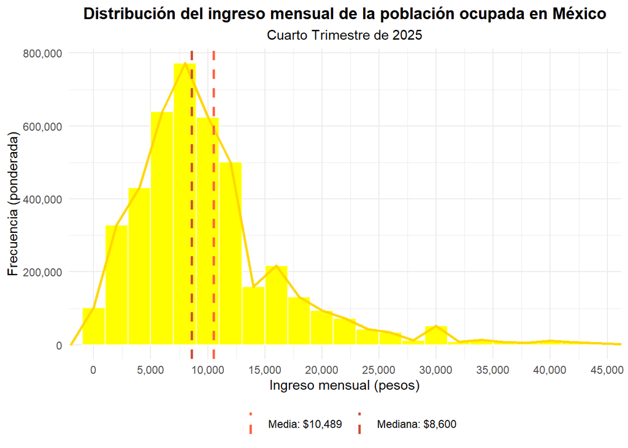

```r
label_media_ingreso   <- paste0("Media: $", comma(round(media_ingreso, 0)))
label_mediana_ingreso <- paste0("Mediana: $", comma(round(mediana_ingreso, 0)))

ggplot(ocupados %>% filter(ingocup > 0), aes(x = ingocup, weight = ponderador)) +
  geom_histogram(binwidth = 2000, fill = "yellow", color = "white") +
  geom_freqpoly(binwidth = 2000, color = "gold", linewidth = 1) +
  geom_vline(aes(xintercept = media_ingreso, color = label_media_ingreso),
             linetype = "dashed", linewidth = 1) +
  geom_vline(aes(xintercept = mediana_ingreso, color = label_mediana_ingreso),
             linetype = "dashed", linewidth = 1) +
  scale_color_manual(name = "", values = setNames(c("tomato", "tomato3"),
                                                    c(label_media_ingreso, label_mediana_ingreso))) +
  coord_cartesian(xlim = c(0, wtd.quantile(ocupados$ingocup, ocupados$ponderador, 0.99, na.rm = TRUE))) +
  scale_x_continuous(labels = comma, breaks = pretty_breaks(n = 10)) +
  scale_y_continuous(labels = comma) +
  labs(title = "Distribución del ingreso mensual de la población ocupada en México",
       subtitle = "Cuarto Trimestre de 2025",
       x = "Ingreso mensual (pesos)",
       y = "Frecuencia (ponderada)") +
  theme_minimal() +
  theme(plot.title = element_text(face = "bold", hjust = 0.5),
        plot.subtitle = element_text(hjust = 0.5),
        legend.position = "bottom")
```

## 9. Deciles de ingreso

Un decil divide a la población en 10 grupos iguales, del 10% que menos gana (decil 1) al 10% que más gana (decil 10). Usamos `wtd.quantile()` para encontrar los puntos de corte tomando en cuenta el ponderador:

```r
# 1. Calculamos los puntos de corte de cada decil (0%, 10%, 20%, ..., 100%).
cortes_ingreso <- wtd.quantile(
  ocupados$ingocup,
  weights = ocupados$ponderador,
  probs = seq(0, 1, by = 0.1),
  na.rm = TRUE
)
cortes_ingreso
```

```
##     0%    10%    20%    30%    40%    50%    60%    70%    80%    90%   100%
##     67   3010   5160   6450   7740   8600  10320  12000  14000  18000 200000
```

```r
# 2. Clasificamos a cada persona en su decil correspondiente usando cut().
ocupados <- ocupados %>%
  mutate(decil_ingreso = cut(
    ingocup,
    breaks = cortes_ingreso,
    labels = 1:10,
    include.lowest = TRUE
  ))

# 3. Calculamos, para cada decil, cuánta gente representa y cuál es su
# ingreso promedio.
resumen_deciles <- ocupados %>%
  filter(!is.na(decil_ingreso)) %>%
  group_by(decil_ingreso) %>%
  summarise(
    poblacion_ponderada = sum(ponderador, na.rm = TRUE),
    ingreso_promedio_ponderado = weighted.mean(ingocup, ponderador, na.rm = TRUE),
    .groups = "drop"
  ) %>%
  mutate(pct_poblacion = poblacion_ponderada / sum(poblacion_ponderada) * 100)

resumen_deciles
```

| decil_ingreso | poblacion_ponderada | ingreso_promedio_ponderado | pct_poblacion |
| --- | --- | --- | --- |
| 1 | 466221 | 1807.464 | 10.813552 |
| 2 | 531783 | 4322.546 | 12.334200 |
| 3 | 421743 | 6217.860 | 9.781927 |
| 4 | 318568 | 7460.486 | 7.388881 |
| 5 | 484483 | 8440.805 | 11.237122 |
| 6 | 415066 | 9619.051 | 9.627061 |
| 7 | 389563 | 11084.215 | 9.035543 |
| 8 | 481857 | 12975.122 | 11.176214 |
| 9 | 382553 | 16012.358 | 8.872953 |
| 10 | 419614 | 29319.942 | 9.732547 |

Graficamos el ingreso promedio de cada decil:

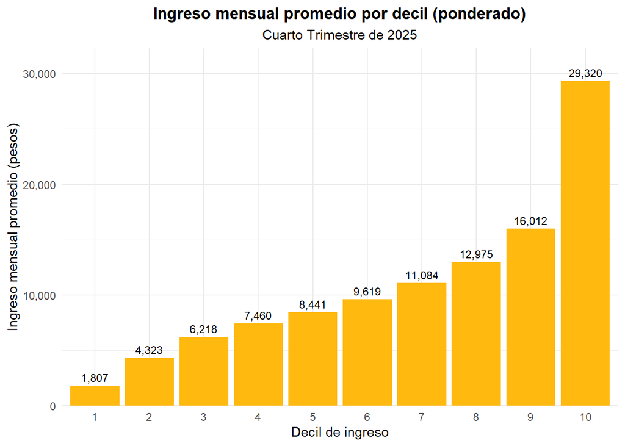

```r
ggplot(resumen_deciles, aes(x = decil_ingreso, y = ingreso_promedio_ponderado)) +
  geom_col(fill = "#FFB90F") +
  geom_text(aes(label = comma(round(ingreso_promedio_ponderado, 0))),
            vjust = -0.5, size = 3.2) +
  scale_y_continuous(labels = comma, expand = expansion(mult = c(0, 0.1))) +
  labs(title = "Ingreso mensual promedio por decil (ponderado)",
       subtitle = "Cuarto Trimestre de 2025",
       x = "Decil de ingreso",
       y = "Ingreso mensual promedio (pesos)") +
  theme_minimal() +
  theme(plot.title = element_text(hjust = 0.5, face = "bold"),
        plot.subtitle = element_text(hjust = 0.5))
```

Y qué porcentaje del ingreso total se lleva cada decil (esto nos ayuda a ver qué tan desigual es la distribución del ingreso):

```r
participacion_decil <- ocupados %>%
  filter(!is.na(decil_ingreso)) %>%
  group_by(decil_ingreso) %>%
  summarise(
    ingreso_total_decil = sum(ingocup * ponderador, na.rm = TRUE),
    .groups = "drop"
  ) %>%
  mutate(pct_ingreso_total = ingreso_total_decil / sum(ingreso_total_decil) * 100)

participacion_decil
```

| decil_ingreso | ingreso_total_decil | pct_ingreso_total |
| --- | --- | --- |
| 1 | 842677859 | 1.863462 |
| 2 | 2298656337 | 5.083150 |
| 3 | 2622338755 | 5.798927 |
| 4 | 2376672020 | 5.255671 |
| 5 | 4089426424 | 9.043182 |
| 6 | 3992541175 | 8.828934 |
| 7 | 4318000014 | 9.548640 |
| 8 | 6252153178 | 13.825743 |
| 9 | 6125575430 | 13.545835 |
| 10 | 12303057996 | 27.206455 |

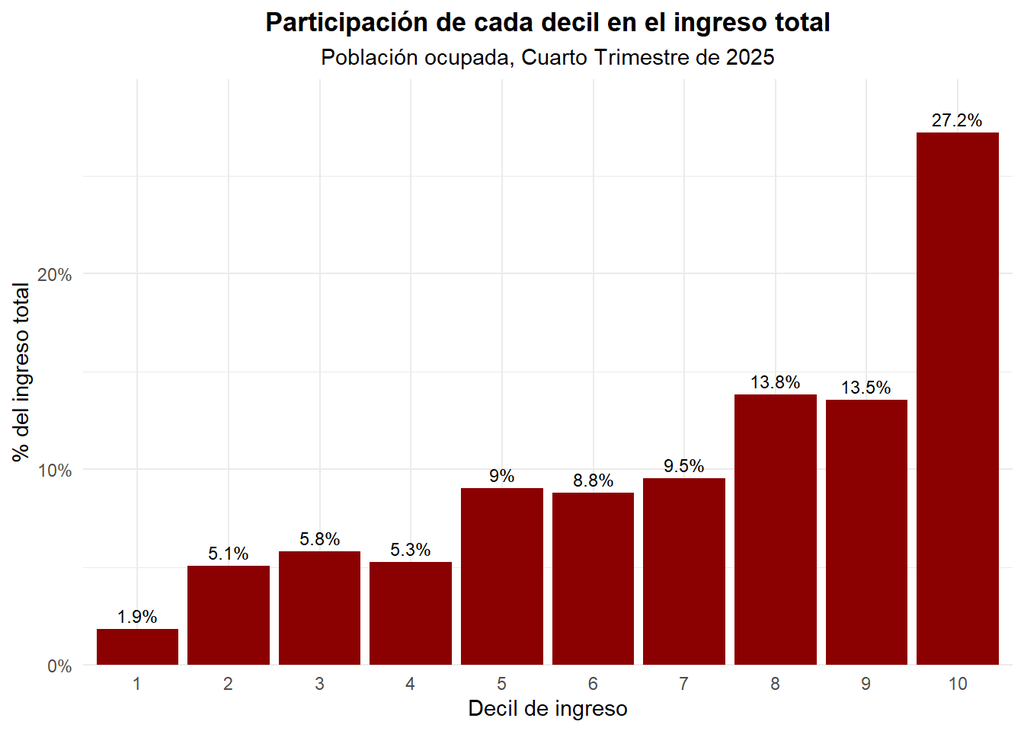

```r
ggplot(participacion_decil, aes(x = decil_ingreso, y = pct_ingreso_total)) +
  geom_col(fill = "darkred") +
  geom_text(aes(label = paste0(round(pct_ingreso_total, 1), "%")),
            vjust = -0.5, size = 3.2) +
  scale_y_continuous(labels = function(x) paste0(x, "%"),
                      expand = expansion(mult = c(0, 0.1))) +
  labs(title = "Participación de cada decil en el ingreso total",
       subtitle = "Población ocupada, Cuarto Trimestre de 2025",
       x = "Decil de ingreso",
       y = "% del ingreso total") +
  theme_minimal() +
  theme(plot.title = element_text(hjust = 0.5, face = "bold"),
        plot.subtitle = element_text(hjust = 0.5))
```

## 10. Relación entre variables: correlación

Hasta ahora hemos visto cada variable por separado. Ahora vamos a ver si existe relación entre varias variables numéricas al mismo tiempo: edad, escolaridad, ingreso, ingreso por hora y horas trabajadas.

```r
# Nos quedamos solo con las columnas numéricas que nos interesan, y
# eliminamos las filas que tengan algún NA en esas columnas (na.omit()),
# porque cor() no puede trabajar con NA.
variables_numericas <- ocupados %>%
  select(edad, escolaridad, ingocup, ing_x_hrs, horas) %>%
  na.omit()

# cor() calcula el coeficiente de correlación entre cada par de columnas.
# Un valor cercano a 1 significa relación positiva fuerte; cercano a -1,
# relación negativa fuerte; cercano a 0, poca relación lineal.
matriz_correlacion <- cor(variables_numericas)
round(matriz_correlacion, 2)
```

```
##              edad escolaridad ingocup ing_x_hrs horas
## edad         1.00       -0.18    0.00      0.04 -0.06
## escolaridad -0.18        1.00    0.22      0.15  0.01
## ingocup      0.00        0.22    1.00      0.57  0.25
## ing_x_hrs    0.04        0.15    0.57      1.00 -0.28
## horas       -0.06        0.01    0.25     -0.28  1.00
```

Y la graficamos con un correlograma:

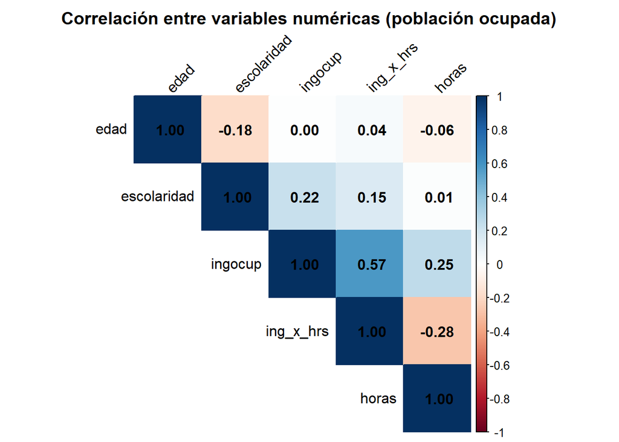

```r
corrplot(matriz_correlacion, method = "color", type = "upper",
         addCoef.col = "black", tl.col = "black", tl.srt = 45,
         title = "Correlación entre variables numéricas (población ocupada)",
         mar = c(0, 0, 2, 0))
```

## 11. La lección final: ¿qué cambia si ponderamos?

Como mencionamos al inicio, la ENOE es una encuesta por muestreo: cada persona representa a `ponderador` personas en la población real. Vamos a recalcular los tres indicadores del mercado laboral, esta vez usando el ponderador, y a comparar el resultado con lo que obtuvimos sin ponderar en la sección 6.

Nota: aunque en este laboratorio ya no analizamos a fondo a la población desocupada (edad, distribución, etc.), sí seguimos necesitando el grupo `desocupados` para poder calcular la **tasa de desocupación**, que es uno de los tres indicadores del mercado laboral.

```r
# Tasa de participación ponderada: sumamos el ponderador de la PEA y lo
# dividimos entre la suma del ponderador de la PET.
tasa_participacion_ponderada <- sum(PEA$ponderador, na.rm = TRUE) /
  sum(PET$ponderador, na.rm = TRUE) * 100

# Tasa de desocupación ponderada.
tasa_desocupacion_ponderada <- sum(desocupados$ponderador, na.rm = TRUE) /
  sum(PEA$ponderador, na.rm = TRUE) * 100

# Tasa de ocupación ponderada.
tasa_ocupacion_ponderada <- sum(ocupados$ponderador, na.rm = TRUE) /
  sum(PET$ponderador, na.rm = TRUE) * 100

# Armamos una tabla comparativa.
comparacion_indicadores <- data.frame(
  indicador = c("Tasa de participación", "Tasa de desocupación", "Tasa de ocupación"),
  sin_ponderar = round(c(tasa_participacion, tasa_desocupacion, tasa_ocupacion), 2),
  ponderado = round(c(tasa_participacion_ponderada, tasa_desocupacion_ponderada,
                       tasa_ocupacion_ponderada), 2)
)

comparacion_indicadores
```

| indicador | sin_ponderar | ponderado |
| --- | --- | --- |
| Tasa de participación | 60.37 | 59.79 |
| Tasa de desocupación | 2.45 | 2.40 |
| Tasa de ocupación | 58.89 | 58.36 |

**Pregunta para reflexionar:** ¿los indicadores cambiaron mucho o poco al ponderar? ¿Por qué crees que pasa esto? Esta es la razón por la que, en un análisis real del mercado laboral, casi nunca se debe ignorar el ponderador.

## 12. (Opcional) Guardar nuestros resultados

Si quieres guardar las tablas que construiste para usarlas después (por ejemplo, en un reporte), puedes exportarlas a `.csv`:

```r
dir.create("salidas", showWarnings = FALSE)

write.csv(comparacion_indicadores, "salidas/comparacion_indicadores.csv", row.names = FALSE)
write.csv(resumen_deciles, "salidas/resumen_deciles_ingreso.csv", row.names = FALSE)
```